# ECOOP 2015 Author Survey

J. Vitek, for the AITO Steering Committee

March 29, 2015

## Population

This survey was sent to all authors of submission to the ECOOP conference in February 2015 during the reviewing period (i.e. before decisions were made). There were **78** responses. The majority, 69%, were authors of previous ECOOP publications.

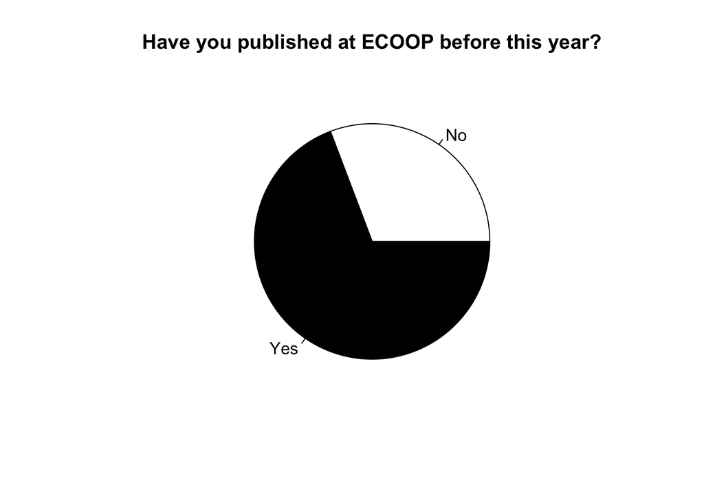

## Publisher

When asked their opinion of LNCS the majority of respondent is neutral or negative. There was a majority, 79% in favor of using LIPIcs.

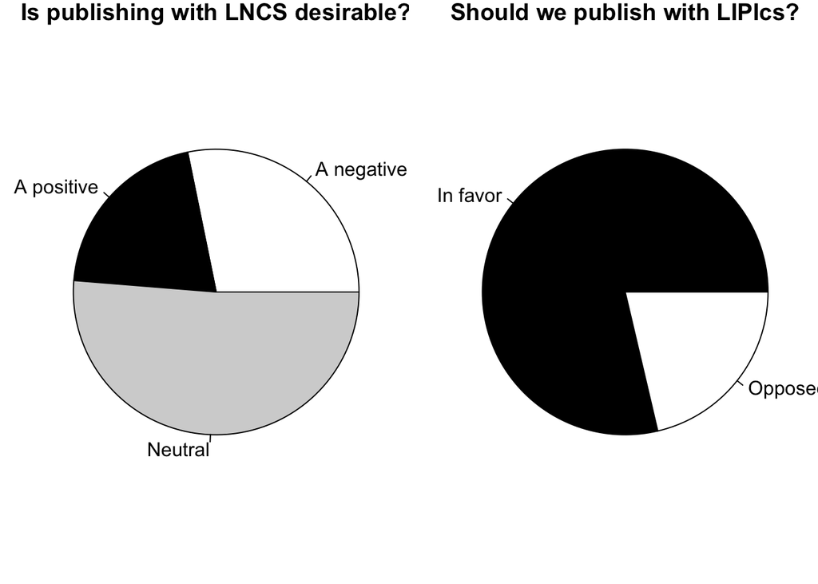

## View of Open Access

When asked about their view of open access the majority of respondent felt that it is in the best interest of Acdemia, Industry and Society at large.

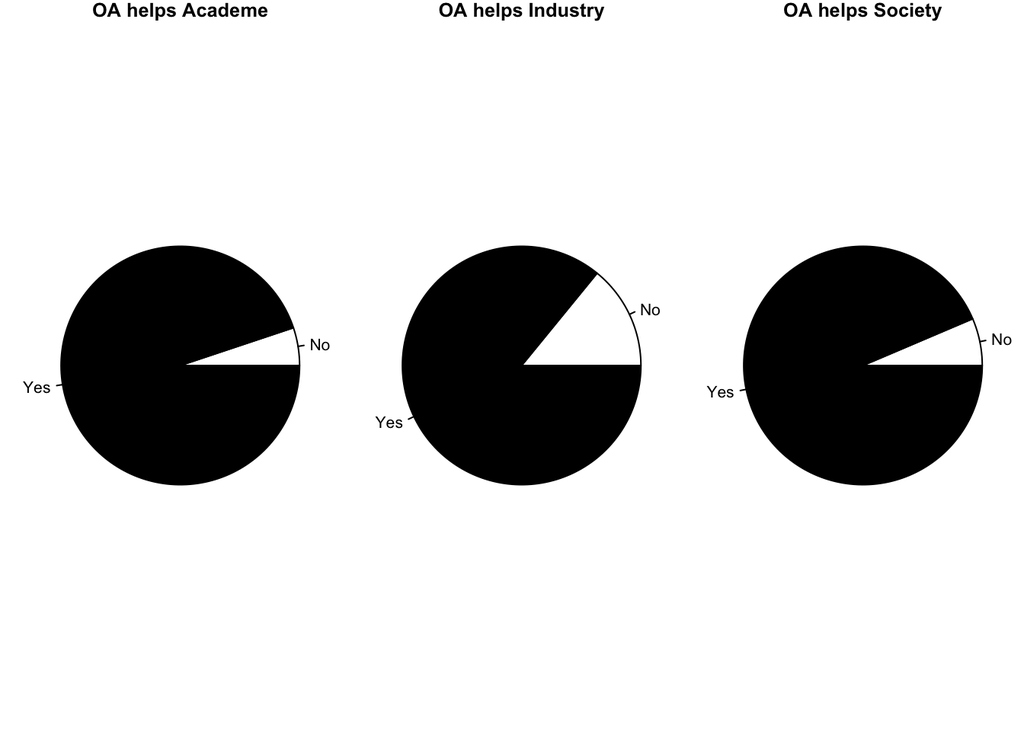

## Switching to OA

When asked if they would support ECOOP moving to an open access publishing model (in the abstract), 88% of respondent answered “Yes”.

A switch to LIPIcs in 2016 was supported by 84% of respondents, while a switch in 2015 was supported by 73% of the authors.

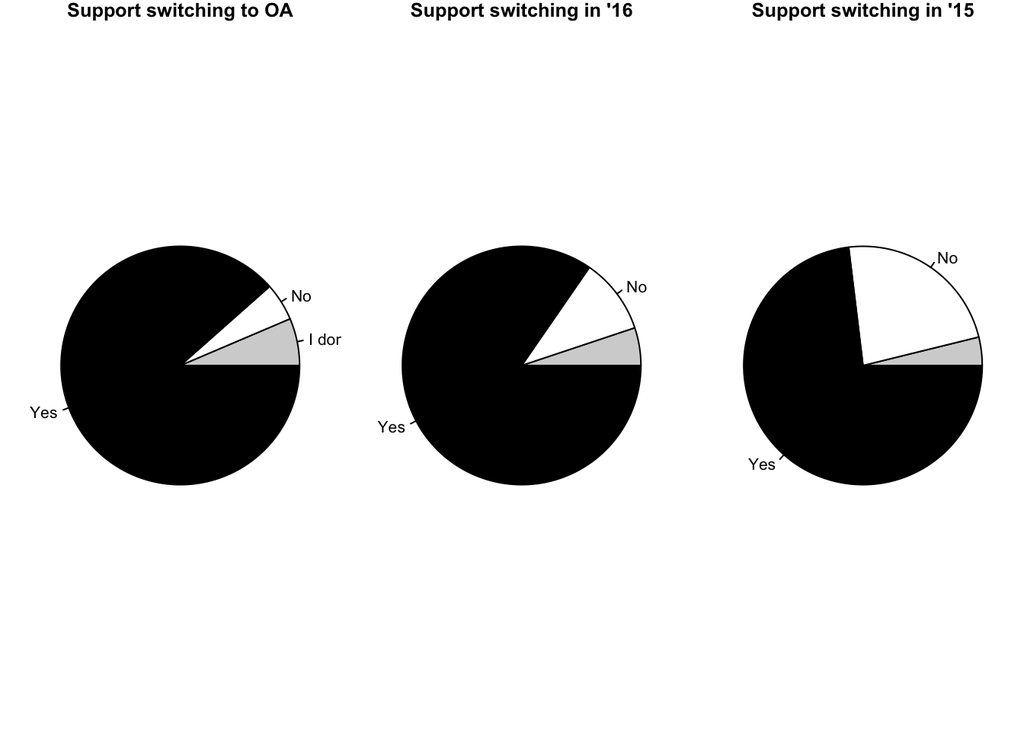

## Comments

The respondents were asked to provide textual comments about OA.

```
##  [1] I don't know the details of Dagstuhl LIPIcs, so my answers are more about open access in general.
##  [2] Springer provides no value to our community, while we donate our hard work to them. We should switch ASAP.
##  [3] I am in favor of open access publishing. The Open Access charge for Dagstuhl LIPIcs seems reasonable.\n\nAdditionally, one aspect of LNCS that I am not fond of is its document style. A point in Dagstuhl LIPIcs's favor is that its document style looks more appealing.
##  [4] Dagstuhl is a highly reputed institution backed by the German version of the U.S. NSF. the fee is low and open access is offered. What else does anyone need ?
##  [5] time to change.  I've dealt with Springer in the past.  Awful.  Their thinking and technology is out of the 1980s -- last century.  \n\n
##  [6] I am in favor of an open-access publisher as long as it is prestigious and does not take anything away from the importance of this conference
##  [7] This is the morally correct thing to do. It will influence me to submit to ECOOP rather than SPLASH.
##  [8] Gradual change is preferable over sudden change
##  [9] I have no LNCS subscription, and there are even ECOOP 2014 papers that you can't find via a Google search; it's been a big pain.  Let's switch for ECOOP 2015!
## [10] I am not a huge fan of the specific format / style, but in general in favor of switching to an open access model.\n\nChanging in 2015 would affect people who submitted, expecting publication in LNCS, so I would suggest 2016.\n
## [11] LNCS is well known and thus makes ECOOP proceedings easier to present to journal heavy committees judging promotions and dismissing conference proceedings. It would make it a harder sell if it is a lesser known publisher. :-(
## [12] Good move, full support.
## [13] While switching to a different publisher it might be interesting to switch to a more user friendly two columns format.
## [14] From 2015 onwards, my research institute requires all publications from publicly funded research to be published according to the open-access principle. In facts it is a policy by the national research council of the Netherlands and thus mandatory for plenty of other research institutes as w…
## [15] The last two "No"s are a bit harsh - I am not in favor of it, but I would\nconsider LIPIcs also as a worthy option.
## [16] My main concern with LIPIcs is that the layout is ugly. The text is too wide (too many characters on a line) and there is too much space between lines yielding the impression of a soup of letters rather than a tight block of text. Also, the yellow backgrounds are in poor taste. The LIPIcs we…
## [17] I strongly welcome the initiative.  (Re)publishing papers on institutional websites is hard to do systematically due to overall busyness.  A proper publisher would save us time, and increase the ranking of papers in search engines.  In particular, I like the LIPIcs idea, as the reputation is…
## [18] The most important aspect for me would be the ACM DL entry for the published paper.
## [19] My institution has no idea of what LIPIcs is, and I worry that papers published there would not be considered in the annual assessment of my productivity.
## [20] At ECOOP 87, I was really happy to own a book with my name inside!\nI must confess that I became, gradually, rather indifferent.\nI suppose that young authors may still be happy with such a material honor, but the cost of print books is too high for them.\nI remember that, in Paphos, my proc…
## [21] PeerJ is starting a Computer Science journal and is also interested in publishing conference proceedings. It might be worth checking out and comparing.
## [22] I would prefer if ECOOP could switch to an OA journal, even though this would take more time (ECOOP 17 or 18?). I would support  Dagstuhl LIPIcs only if there are no valid alternatives for an OA journal, and I would prevent ECOOP from changing publisher twice in a short time.
## [23] There are a couple more things that bother me about Springer.\n\nFirst, they recompile LaTeX from source instead of just taking a PDF, and their light edits often do more harm than good.\n\nSecond, the format (single column text with humongous margins) is a waste of paper when printed.
## [24] Would it be possible to combine Dagstuhl LIPIcs with the arXiv?\n\nhttp://en.wikipedia.org/wiki/ArXiv\nhttp://en.wikipedia.org/wiki/Self-archiving
## [25] I fully support switching to an open-access publisher, since, as a PhD student, I do want to have my work readily available for anyone to read, understand and maybe, as a result, cite it.\n\nSince I am allowed to publish the paper on my website and my institutional repository, engines such a…
## [26] Thank you very much for considering to support Open Access!\n\nThe only reason I can accept seeing my work behind a Springer-paywall is the knowledge that the green way (co-publication on a pre-print server) ensures that there will always also be a freely available version. I would very much…
## [27] Unfortunately, in Slovakia, this is a matter of the publication category.Papers published with worldwide renowned organizations like IFAC, IFIP, IEEE, ACM, IET, SPIE, or worldwide renowned publishers like Springer, Elsevier, John Wiley are a category above regular international conferences.
## [28] Switching this year does not seem legit as it is announced after the paper submission deadline.  Some researchers may not be positive about it.\n\nBefore switching, some more details may be worth discussing: \n- availability of latex template\n- perceived quality of other publications by the…
## [29] It's about time to go open access. Concur has done that for the 1st time this year, after a 25 years marriage to LNCS.\nI often end up at Springer's site with a 35 euros barrier between me and the paper that I want to read.\nNow the question about the 15 euros is not clear to me. Do you inte…
## 30 Levels:  ...
```

### Repeatability

A PDF file with questions asked in this poll is [here](http://janvitek.org/who/ecoop/survey.pdf).

A CSV file with answers is [here](http://janvitek.org/who/ecoop/data.csv)

A PDF file with the Google Form overview of the responses is [here](http://janvitek.org/who/ecoop/results.pdf).

The R Markdown code for this document is [here](http://janvitek.org/who/ecoop/index.Rmd).

### Acknowledgments

Shriram Krishnamurthi provided the impetus for this poll, thanks!